# Homework 3 Solutions

Vasili Fokaidis

2020-10-09

```r
library(tidyverse)
```

```r
library(p8105.datasets)

knitr::opts_chunk$set(
  fig.width = 6,
  fig.asp = 0.6,
  out.width = "90%"
)

theme_set(theme_minimal() + theme(legend.position = "bottom"))

options(
  ggplot2.continuous.colour = "viridis",
  ggplot2.continuous.fill = "viridis"
)

scale_colour_discrete = scale_colour_viridis_d
scale_fill_discrete = scale_fill_viridis_d
```

## Problem 1

```r
data("instacart")
```

There are 1384617 rows and 15 columns in the instacart dataset. The data reflects the level of items in orders by user. There are user and order variables such as: user/order ID, order day, and order hour. And, there are item variables such as: product name, aisle, department, and some numeric codes.

How many aisles are there, and which aisles are the most items ordered from?

```r
instacart %>%
  count(aisle) %>%
  arrange(desc(n))
```

```
## # A tibble: 134 x 2
##    aisle                              n
##    <chr>                          <int>
##  1 fresh vegetables              150609
##  2 fresh fruits                  150473
##  3 packaged vegetables fruits     78493
##  4 yogurt                         55240
##  5 packaged cheese                41699
##  6 water seltzer sparkling water  36617
##  7 milk                           32644
##  8 chips pretzels                 31269
##  9 soy lactosefree                26240
## 10 bread                          23635
## # … with 124 more rows
```

There are 134 different aisles and most items are ordered from the fresh vegetables, fresh fruits, packaged vegetables fruits, and yogurt aisles.

Make a plot!

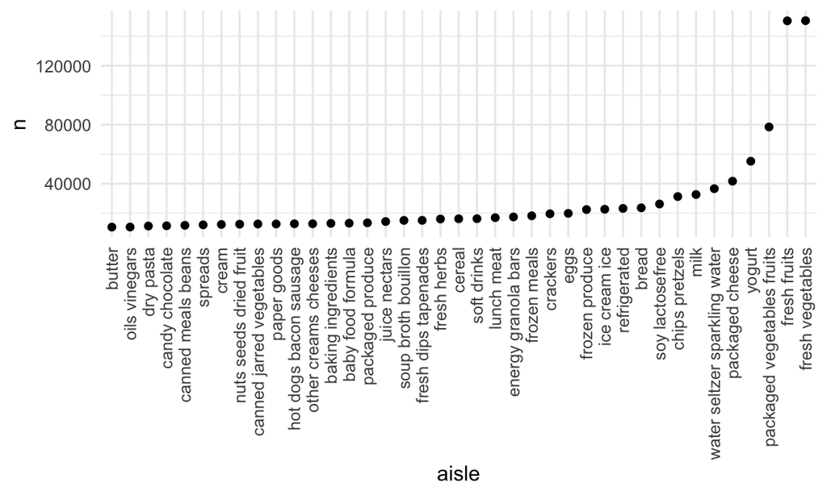

```r
instacart %>%
  count(aisle) %>%
  filter(n > 10000) %>%
  mutate(
      aisle = factor(aisle),
      aisle = fct_reorder(aisle, n)
  ) %>%
  ggplot(aes(x = aisle, y = n)) +
  geom_point() +
  theme(axis.text.x = element_text(angle = 90, vjust = 0.5, hjust = 1))
```

Make a table!

```r
instacart %>%
  filter(aisle %in% c("baking ingredients", "dog food care", "packaged vegetables fruits")) %>%
  group_by(aisle) %>%
  count(product_name) %>%
  mutate(rank = min_rank(desc(n))) %>%
  filter(rank < 4) %>%
  arrange(aisle, rank) %>%
  knitr::kable()
```

| aisle | product_name | n | rank |
| --- | --- | --- | --- |
| baking ingredients | Light Brown Sugar | 499 | 1 |
| baking ingredients | Pure Baking Soda | 387 | 2 |
| baking ingredients | Cane Sugar | 336 | 3 |
| dog food care | Snack Sticks Chicken & Rice Recipe Dog Treats | 30 | 1 |
| dog food care | Organix Chicken & Brown Rice Recipe | 28 | 2 |
| dog food care | Small Dog Biscuits | 26 | 3 |
| packaged vegetables fruits | Organic Baby Spinach | 9784 | 1 |
| packaged vegetables fruits | Organic Raspberries | 5546 | 2 |
| packaged vegetables fruits | Organic Blueberries | 4966 | 3 |

Apple vs. Ice Cream Table

```r
instacart %>%
  filter(product_name %in% c("Pink Lady Apples", "Coffee Ice Cream")) %>%
  group_by(product_name, order_dow) %>%
  summarize(mean_hour = mean(order_hour_of_day)) %>%
  pivot_wider(
    names_from = order_dow,
    values_from = mean_hour
  )
```

```
## # A tibble: 2 x 8
## # Groups:   product_name [2]
##   product_name       `0`   `1`   `2`   `3`   `4`   `5`   `6`
##   <chr>            <dbl> <dbl> <dbl> <dbl> <dbl> <dbl> <dbl>
## 1 Coffee Ice Cream  13.8  14.3  15.4  15.3  15.2  12.3  13.8
## 2 Pink Lady Apples  13.4  11.4  11.7  14.2  11.6  12.8  11.9
```

## Problem 2

Load, tidy, and wrangle the accel data. (Weekend vs weekday variable????????)

```r
accel_data =
  read.csv("./data/accel_data.csv") %>%
  pivot_longer(
    activity.1:activity.1440,
    names_to = "minute",
    names_prefix = "activity.",
    values_to = "activity counts",
  ) %>%
  janitor::clean_names() %>%
  mutate(
    minute = as.numeric(minute),
    day = as.factor(day)
  )
```

Aggregate across minutes to create a total activity variable for each day and create a table. (Not giving numbers in table!!)

```r
accel_data %>%
  filter(day %in% c("Friday", "Saturday", "Sunday", "Monday", "Tuesday", "Wednesday", "Thursday")) %>%
  group_by(week, day) %>%
  summarize(total_minutes = sum(minute), total_activity_counts = sum(activity_counts))
```

```
## # A tibble: 35 x 4
## # Groups:   week [5]
##     week day       total_minutes total_activity_counts
##    <int> <fct>             <dbl>                 <dbl>
##  1     1 Friday          1037520               480543.
##  2     1 Monday          1037520                78828.
##  3     1 Saturday        1037520               376254
##  4     1 Sunday          1037520               631105
##  5     1 Thursday        1037520               355924.
##  6     1 Tuesday         1037520               307094.
##  7     1 Wednesday       1037520               340115.
##  8     2 Friday          1037520               568839
##  9     2 Monday          1037520               295431
## 10     2 Saturday        1037520               607175
## # … with 25 more rows
```

```r
accel_data
```

```
## # A tibble: 50,400 x 5
##     week day_id day    minute activity_counts
##    <int>  <int> <fct>   <dbl>           <dbl>
##  1     1      1 Friday      1            88.4
##  2     1      1 Friday      2            82.2
##  3     1      1 Friday      3            64.4
##  4     1      1 Friday      4            70.0
##  5     1      1 Friday      5            75.0
##  6     1      1 Friday      6            66.3
##  7     1      1 Friday      7            53.8
##  8     1      1 Friday      8            47.8
##  9     1      1 Friday      9            55.5
## 10     1      1 Friday     10            43.0
## # … with 50,390 more rows
```

## Problem 3

```r
library(p8105.datasets)
data("ny_noaa")
```

Describe NY NOAA dataset.

```r
names(ny_noaa)
```

```
## [1] "id"   "date" "prcp" "snow" "snwd" "tmax" "tmin"
```

```r
head(ny_noaa)
```

```
## # A tibble: 6 x 7
##   id          date        prcp  snow  snwd tmax  tmin
##   <chr>       <date>     <int> <int> <int> <chr> <chr>
## 1 US1NYAB0001 2007-11-01    NA    NA    NA <NA>  <NA>
## 2 US1NYAB0001 2007-11-02    NA    NA    NA <NA>  <NA>
## 3 US1NYAB0001 2007-11-03    NA    NA    NA <NA>  <NA>
## 4 US1NYAB0001 2007-11-04    NA    NA    NA <NA>  <NA>
## 5 US1NYAB0001 2007-11-05    NA    NA    NA <NA>  <NA>
## 6 US1NYAB0001 2007-11-06    NA    NA    NA <NA>  <NA>
```

The NY NOAA dataset has 2595176 rows and 7 columns. The dataset contains 3387623 total missing observations which could cause some issues in deducing important statistics. Important variables are the weather station ID, date of observation, precipitation (mm), snowfall, snow depth (mm), maximum temperature, and minimum temperature.

Do some data cleaning!

```r
ny_noaa %>%
  janitor::clean_names() %>%
   separate(
        date,
        into = c('year', 'month', 'day'),
        convert = TRUE
      ) %>%
  mutate(
    tmax = as.numeric(tmax),
    tmin = as.numeric(tmin),
    tmax = tmax/10,
    tmin = tmin/10,
    prcp = prcp/10
  )
```

```
## # A tibble: 2,595,176 x 9
##    id           year month   day  prcp  snow  snwd  tmax  tmin
##    <chr>       <int> <int> <int> <dbl> <int> <int> <dbl> <dbl>
##  1 US1NYAB0001  2007    11     1    NA    NA    NA    NA    NA
##  2 US1NYAB0001  2007    11     2    NA    NA    NA    NA    NA
##  3 US1NYAB0001  2007    11     3    NA    NA    NA    NA    NA
##  4 US1NYAB0001  2007    11     4    NA    NA    NA    NA    NA
##  5 US1NYAB0001  2007    11     5    NA    NA    NA    NA    NA
##  6 US1NYAB0001  2007    11     6    NA    NA    NA    NA    NA
##  7 US1NYAB0001  2007    11     7    NA    NA    NA    NA    NA
##  8 US1NYAB0001  2007    11     8    NA    NA    NA    NA    NA
##  9 US1NYAB0001  2007    11     9    NA    NA    NA    NA    NA
## 10 US1NYAB0001  2007    11    10    NA    NA    NA    NA    NA
## # … with 2,595,166 more rows
```